# Visualization (Marks and Encoding)

Peter Ganong and Maggie Shi

January 14, 2026

# Roadmap of the lecture

- Data for this lecture
- Fundamentals of data visualization
  - Data types: what information is in my data?
  - Encoding and marks: how do I want to convey this information?
- Applying this in `altair`

# Global Health Data

## Introducing global health data

- Throughout the rest of lecture, we will be visualizing global health and population data for a number of countries, over the time period of 1955 to 2005.
- The data was collected by the [Gapminder Foundation](https://www.gapminder.org/) and shared in [Hans Rosling’s fantastic TED talk](https://www.youtube.com/watch?v=hVimVzgtD6w).
- Roadmap: load data and review first five rows

## Load data

Let’s first load the dataset from the vega-datasets collection into a Pandas data frame.

```python
import altair as alt
from vega_datasets import data as vega_data
data = vega_data.gapminder()
data["cluster_name"] = data["cluster"].map({
    0: "South Asia",
    1: "Western Europe",
    2: "Sub-Saharan Africa",
    3: "Americas & Anglos",
    4: "East Asia",
    5: "Middle East & North Africa"
})
```

*(Note: we deviate from Heer et al. do some data cleaning to fix a poorly defined variable, `cluster`)*

## Load data

```python
data.head(4)
```

[output not shown]

## data summary

For each `country` and `year` (in 5-year intervals), we have:

- `fertility`: fertility in terms of the number of children per woman
- `life_expect`: life expectancy in years
- `pop`: total population
- `cluster_name`: region

# Fundamentals of visualization: Data Types

## Data types: intro and roadmap

Core **data types**, as recognized by `altair`:

- `'N'`: *nominal* type
- `'O'`: *ordinal* type
- `'Q'`: *quantitative* type
- `'T'`: *temporal* type

## Nominal (N)

- *Nominal* data consists of **unordered** category names.
  - Also called *categorical* data
- **Questions**: *Is value A the same or different from value B? (A = B)*?
- **Answers**: conclusion we should be able to try is whether the values are the same or different
- **In `gapminder` data**: the `country` field is `N`ominal

## Ordinal (O)

- *Ordinal* data consist of values that have a specific **rank-ordering**.
  - Note: ordinal does not necessarily mean numerical. E.g., survey results: “Good”, “Ok”, “Bad”
- **Questions**: *Does value A come before or after value B? (A < B)*
- **Answers**: statements like “A is less than B” or “A is greater than B”.
- **In `gapminder` data**: `year` field can be treated as `O`rdinal.

## Quantitative (Q)

- *Quantitative* data measures numerical differences among values. Two types: *interval* and *ratio*
  - *Interval* data
    - Questions: *what is the distance to value A from value B?*
    - Answers: “A is 12 units away from B”
  - *Ratio* data
    - Questions: *How many are there of value A?*, *Value A is what proportion of value B? (A / B)
    - Answers: “how many babies per parent?”, “A is 10% of B”

## Quantitative (Q), continued

- Key difference between *interval* and *ratio*: 0 is essential for ratio, but not interval data
- *(Note: we are following Heer et al. in use of the term “ratio,” recognizing that they mean it as encompassing more than just ratios)*

## Quantitative (Q), continued

- **In `gapminder` data**: `year` is a quantitative *interval* field
- Whereas `fertility` and `life_expect` are quantitative *ratio* fields – zero is meaningful for calculating proportions
- `altair` represents quantitative data, but does not make a distinction between interval and ratio types

## Quantitative (Q), continued

Discussion questions

- Why is it so important to include zeros for ratio data?
- Can you give an example where omitting zeros on the plot would lead the reader to misleading conclusions?

## Temporal (T)

- *Temporal* values measure time points or intervals.
- Special case of quantitative values (timestamps) with rich semantics and conventions (i.e., the [Gregorian calendar](https://en.wikipedia.org/wiki/Gregorian_calendar)).
- Example temporal values include date strings such as `“2019-01-04”` and `“Jan 04 2019”`
- Also standardized date-times such as the [ISO date-time format](https://en.wikipedia.org/wiki/ISO_8601): `“2019-01-04T17:50:35.643Z”`
- There are no temporal values in our global development dataset above, as the `year` field is simply encoded as an integer.

## Discussion question I

What are examples of variables that are:

- `N`ominal
- `O`rdinal
- `Q`uantitative

Let’s try to come up with at least three examples of each. For each example, state the comparison in a sentence.

## Discussion question II

Suppose we have a dataset of ages (10 years old, 20 years old, 10 years old, 30 years old). What would it mean for these data to be:

- `N`ominal
- `O`rdinal
- `Q`uantitative

What comparisons are feasible with each data type?

## Add data types to last lecture’s plot

```python
seattle = vega_data.seattle_weather()
alt.Chart(seattle).mark_bar().encode(
    alt.X('month(date):O', title = "Month"),
    alt.Y('average(precipitation):Q', title = "Average rainfall (in.)")
)
```

[interactive chart not shown]

- Month: `O`rdinal
- Average rainfall: `Q`uantitative

## Do-pair-share

- What happens when you make `precipitation` `O`rdinal?
- What rank-ordering does `altair` assume when you declare the data ordinal?

Starter code: `viz_2_marksencoding/viz_2_marksencoding_dps.qmd`

```python
seattle = vega_data.seattle_weather()
alt.Chart(seattle).mark_bar().encode(
    alt.X('month(date):O', title = "Month"),
    alt.Y('average(precipitation):Q', title = "Average rainfall (in.)")
)
```

## Data types: summary

A single data series can have multiple meanings depending on data type

- `'N'`: a *nominal* type (unordered, categorical data),
- `'O'`: *ordinal* type (rank-ordered data),
- `'Q'`: *quantitative* type (numerical data with meaningful magnitudes), and
- `'T'`: *temporal* type (date/time data)

Explicitly specify the data type so that `altair` knows how to encode each variable

# Fundamentals of visualization: Encodings

## Visual encodings: roadmap

- Introduce types of visual encodings and rank them by their effectiveness
- More on color

## Citing our sources

- Schwabish: “Better Data Visualizations” [(link to purchase)](https://cup.columbia.edu/book/better-data-visualizations/9780231193115/)
- Healy: “Data Visualization” [(link to full text)](https://socviz.co/)
- Munzner. Visualization Analysis and Design. [(slides and video)](https://www.cs.ubc.ca/~tmm/vadbook/)

## Recall: visualization guidelines

1. All axes and units are properly labeled and legible
2. No words or data points are cut off in your final output
3. **Encodings should be sensible/appropriate** – *what does this mean?*

## Visual encodings

- **Visual encodings** map data variables to visual properties of a chart
- The encoding you choose should be appropriate for the data type and conclusions you want audience to draw
  - Good encodings reveal patterns and makes clear what comparison can be made
  - Bad encodings obfuscate and can be misleading

## Encodings: ordered attributes

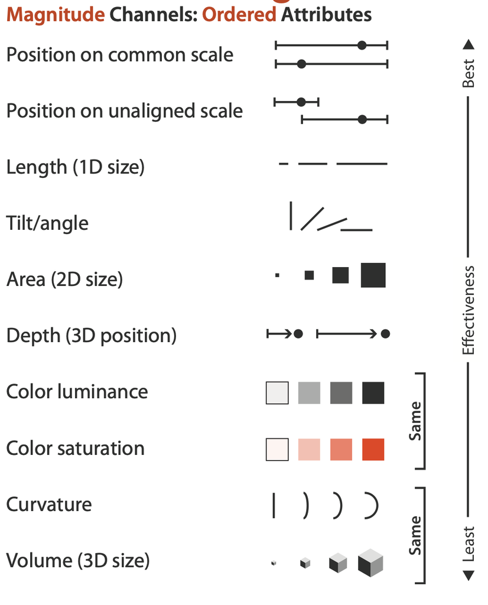

Source: Munzner (2014), Figure 5.6

## Encodings: unordered attributes

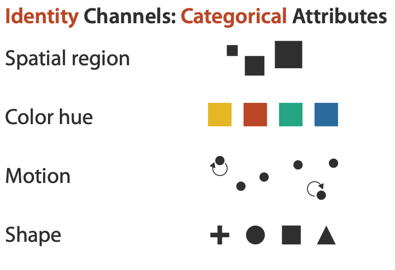

Source: Munzner (2014), Figure 5.6